# Supervised Learning Report

Gaudio Carmelo Garozzo- Mattia Campagna- Davoud Davide Kalantari

2025-03-26

## 1.1. Basic data visualization

```r
ad_train <- read.csv(here("advertising_train.csv"))

# rename (as you did)
colnames(ad_train)[colnames(ad_train) %in% c("Daily.Time.Spent.on.Site", "Daily.Internet.Usage")] <-
  c("DT.on.Site", "DI.Usage")

# drop index column
ad_train <- ad_train %>% select(-X)

# parse timestamp
ad_train <- ad_train %>%
  mutate(
    Timestamp = ymd_hms(Timestamp),
    Male = factor(Male, levels = c(0,1), labels = c("Female","Male")),
    Clicked.on.Ad = factor(Clicked.on.Ad, levels = c(0,1), labels = c("No","Yes"))
  )

str(ad_train)
```

```
## 'data.frame':    800 obs. of  10 variables:
##  $ DT.on.Site   : num  43.7 51.2 64.7 69.6 39.9 ...
##  $ Age          : int  28 36 51 43 41 43 27 38 28 30 ...
##  $ Area.Income  : num  63127 76368 24317 28029 64927 ...
##  $ DI.Usage     : num  173 177 138 255 156 ...
##  $ Ad.Topic.Line: chr  "Front-line bifurcated ability" "Versatile transitional monitoring" "Horizontal incremental website" "Cross-group value-added success" ...
##  $ City         : chr  "Nicholasland" "Timothyfurt" "Andersonfurt" "Port Katelynview" ...
##  $ Male         : Factor w/ 2 levels "Female","Male": 1 1 2 1 1 1 1 2 2 2 ...
##  $ Country      : chr  "Mayotte" "Cuba" "Togo" "Congo" ...
##  $ Timestamp    : POSIXct, format: "2016-04-04 03:57:48" "2016-01-03 16:01:40" ...
##  $ Clicked.on.Ad: Factor w/ 2 levels "No","Yes": 2 2 2 2 2 2 2 2 2 2 ...
```

Where the variables are defined as follows:

X: Variable used as an index DT.on.Site: Indicates the number of minutes a user spends on the website each day.s Age: Age of the user visiting the website. Area.Income: Income of the area where the user is located. DI.Usage: Indicates how many minutes per day a user spends on the Internet in general, not just on the specific website. Ad.Topic.Line: The content of the advertisement. City: City of the user. Male: Binary variable that indicates 1 if the user is male, 0 if the user is female. Country: Country of the user. Timestamp: Indicates when a user viewed the advertisement, including the exact date and time. Clicked.on.Ad: Binary variable that indicates 1 if the user clicked on the advertisement, 0 otherwise.

```r
head(ad_train)
```

```
##   DT.on.Site Age Area.Income DI.Usage                         Ad.Topic.Line
## 1      43.70  28    63126.96   173.01         Front-line bifurcated ability
## 2      51.24  36    76368.31   176.73     Versatile transitional monitoring
## 3      64.67  51    24316.61   138.35        Horizontal incremental website
## 4      69.58  43    28028.74   255.07       Cross-group value-added success
## 5      39.94  41    64927.19   156.30    Function-based optimizing protocol
## 6      45.44  43    48453.55   119.27 Enhanced intermediate standardization
##               City   Male   Country           Timestamp Clicked.on.Ad
## 1     Nicholasland Female   Mayotte 2016-04-04 03:57:48           Yes
## 2      Timothyfurt Female      Cuba 2016-01-03 16:01:40           Yes
## 3     Andersonfurt   Male      Togo 2016-02-14 16:33:29           Yes
## 4 Port Katelynview Female     Congo 2016-04-04 18:36:59           Yes
## 5  Williamsborough Female Lithuania 2016-01-08 22:47:10           Yes
## 6          Mezaton Female     China 2016-05-04 05:01:37           Yes
```

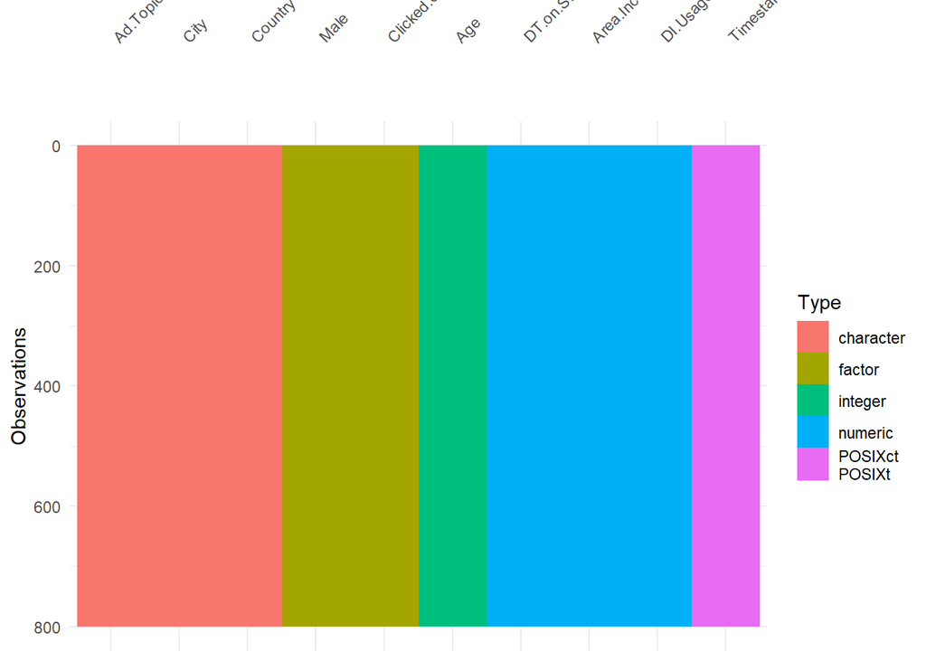

```r
vis_dat(ad_train)
```

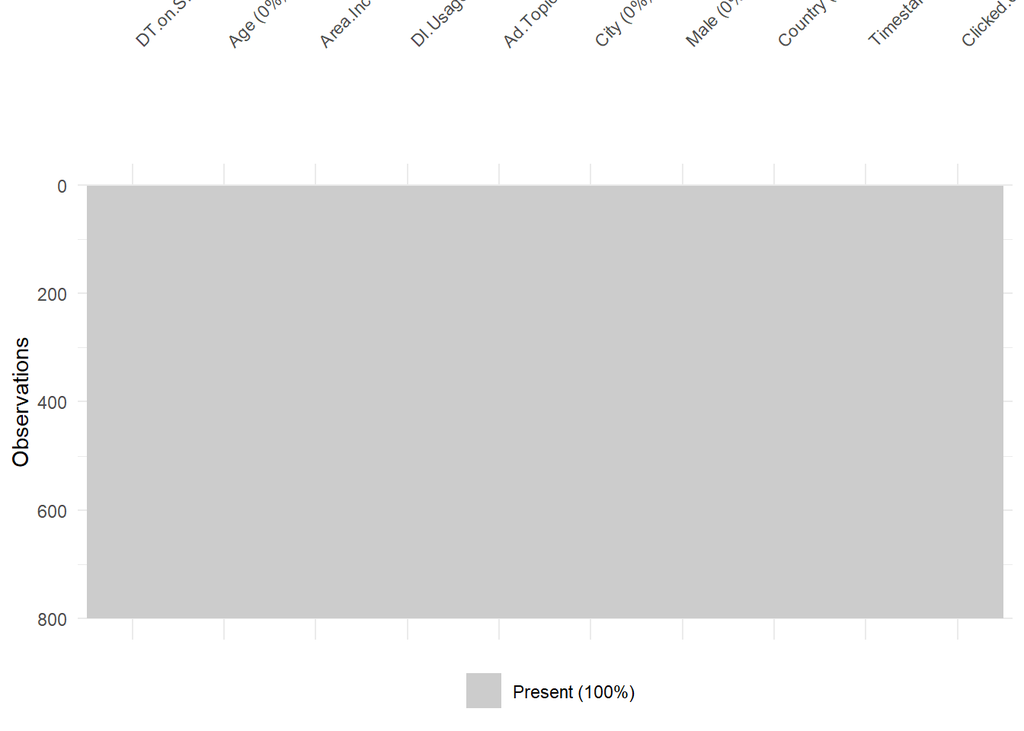

```r
vis_miss(ad_train)
```

We observe that there are no missing values.

```r
skim(ad_train)
```

Data summary

| Name | ad_train |
| --- | --- |
| Number of rows | 800 |
| Number of columns | 10 |
| _______________________ |  |
| Column type frequency: |  |
| character | 3 |
| factor | 2 |
| numeric | 4 |
| POSIXct | 1 |
| ________________________ |  |
| Group variables | None |

**Variable type: character**

| skim_variable | n_missing | complete_rate | min | max | empty | n_unique | whitespace |
| --- | --- | --- | --- | --- | --- | --- | --- |
| Ad.Topic.Line | 0 | 1 | 17 | 55 | 0 | 800 | 0 |
| City | 0 | 1 | 6 | 20 | 0 | 779 | 0 |
| Country | 0 | 1 | 4 | 51 | 0 | 233 | 0 |

**Variable type: factor**

| skim_variable | n_missing | complete_rate | ordered | n_unique | top_counts |
| --- | --- | --- | --- | --- | --- |
| Male | 0 | 1 | FALSE | 2 | Fem: 425, Mal: 375 |
| Clicked.on.Ad | 0 | 1 | FALSE | 2 | No: 400, Yes: 400 |

**Variable type: numeric**

| skim_variable | n_missing | complete_rate | mean | sd | p0 | p25 | p50 | p75 | p100 | hist |
| --- | --- | --- | --- | --- | --- | --- | --- | --- | --- | --- |
| DT.on.Site | 0 | 1 | 64.80 | 15.76 | 32.60 | 51.28 | 67.88 | 78.35 | 91.43 | ▅▅▅▇▆ |
| Age | 0 | 1 | 35.98 | 8.89 | 19.00 | 29.00 | 35.00 | 42.00 | 61.00 | ▅▇▇▃▁ |
| Area.Income | 0 | 1 | 54984.12 | 13409.14 | 13996.50 | 46955.84 | 57228.18 | 65497.57 | 78520.99 | ▁▂▆▇▆ |
| DI.Usage | 0 | 1 | 180.57 | 44.05 | 104.78 | 138.98 | 183.94 | 219.73 | 269.96 | ▇▆▆▇▃ |

**Variable type: POSIXct**

| skim_variable | n_missing | complete_rate | min | max | median | n_unique |
| --- | --- | --- | --- | --- | --- | --- |
| Timestamp | 0 | 1 | 2016-01-01 02:52:10 | 2016-07-24 00:22:16 | 2016-04-06 23:38:52 | 800 |

```r
ad_train_num <- ad_train %>%
  select(DT.on.Site, Age, Area.Income, DI.Usage, Male, Clicked.on.Ad)
s<-apply(ad_train_num,2,sd)
mx<-apply(ad_train_num,2,mean)
cv<-s/mx

df_cv <- data.frame(
  Standard_Deviation = s,
  Mean = mx,
  Coefficient_of_Variation = cv
)

print(df_cv, digits = 3)
```

```
##               Standard_Deviation Mean Coefficient_of_Variation
## DT.on.Site                 15.76   NA                       NA
## Age                         8.89   NA                       NA
## Area.Income             13409.14   NA                       NA
## DI.Usage                   44.05   NA                       NA
## Male                          NA   NA                       NA
## Clicked.on.Ad                 NA   NA                       NA
```

## 1.2. Analysis of univariate statistics

We previously selected the numerical variables and assigned them to a dataframe to be used for this type of analysis, excluding the index variable as it has no statistical relevance.

```r
head(ad_train_num)
```

```
##   DT.on.Site Age Area.Income DI.Usage   Male Clicked.on.Ad
## 1      43.70  28    63126.96   173.01 Female           Yes
## 2      51.24  36    76368.31   176.73 Female           Yes
## 3      64.67  51    24316.61   138.35   Male           Yes
## 4      69.58  43    28028.74   255.07 Female           Yes
## 5      39.94  41    64927.19   156.30 Female           Yes
## 6      45.44  43    48453.55   119.27 Female           Yes
```

```r
R <- cor(ad_train_cont)
R
```

```
##             DT.on.Site        Age Area.Income   DI.Usage
## DT.on.Site   1.0000000 -0.3368912   0.3241277  0.5145715
## Age         -0.3368912  1.0000000  -0.1683027 -0.3660549
## Area.Income  0.3241277 -0.1683027   1.0000000  0.3381137
## DI.Usage     0.5145715 -0.3660549   0.3381137  1.0000000
```

The correlation matrix is computed only on continuous predictors to avoid misleading interpretations involving binary variables.

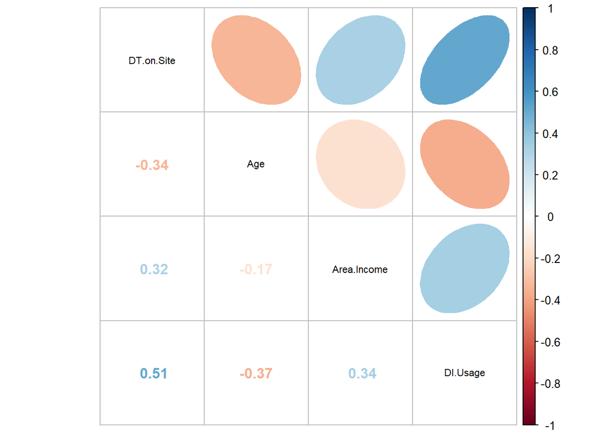

```r
corrplot.mixed(R, upper="ellipse", tl.cex=0.7, tl.col='black')
```

## 1.3. Additional graphical and numerical summaries

Having observed that the variables correlated with our target variable are *DT on Site*, *Age*, *Area Income*, and *DI Usage*, we proceed with a further graphical visualization of their distributions.

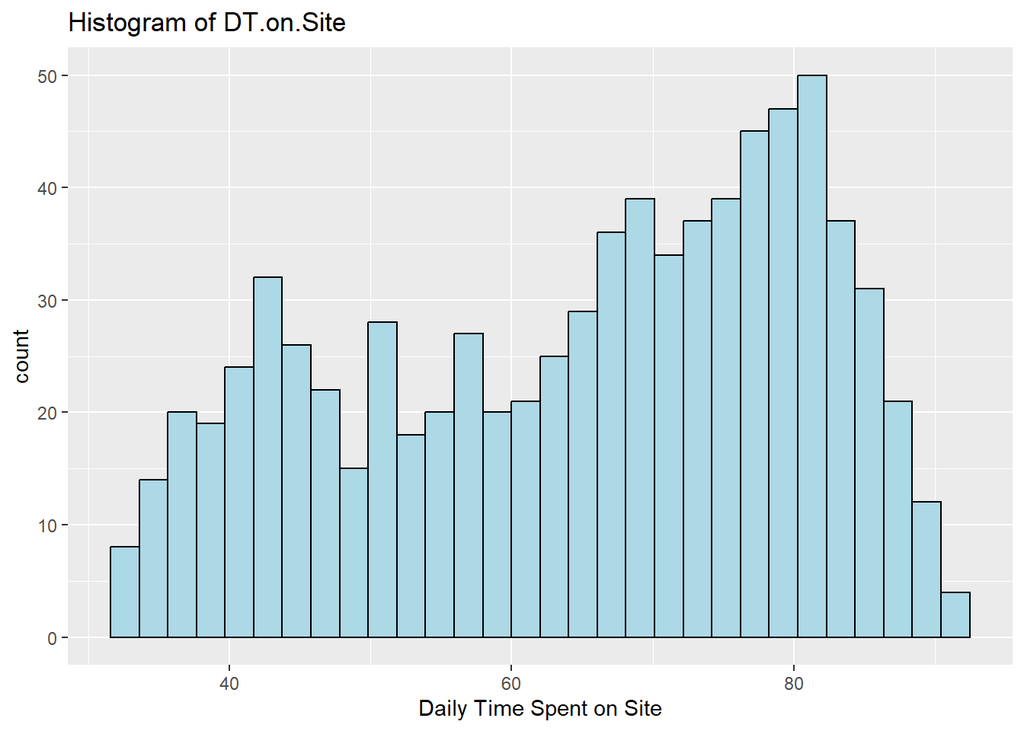

```r
ggplot(ad_train, aes(x = DT.on.Site)) +
  geom_histogram(bins = 30, fill = "lightblue", color = "black") +
  labs(x = "Daily Time Spent on Site", title = "Histogram of DT.on.Site")
```

The histogram shows the distribution with values ranging from approximately 35 to 90. The distribution is uneven, with a main mode between 75 and 85 and secondary peaks, indicating different user engagement patterns. The slight asymmetry suggests that most users spend a relatively long time on the site.

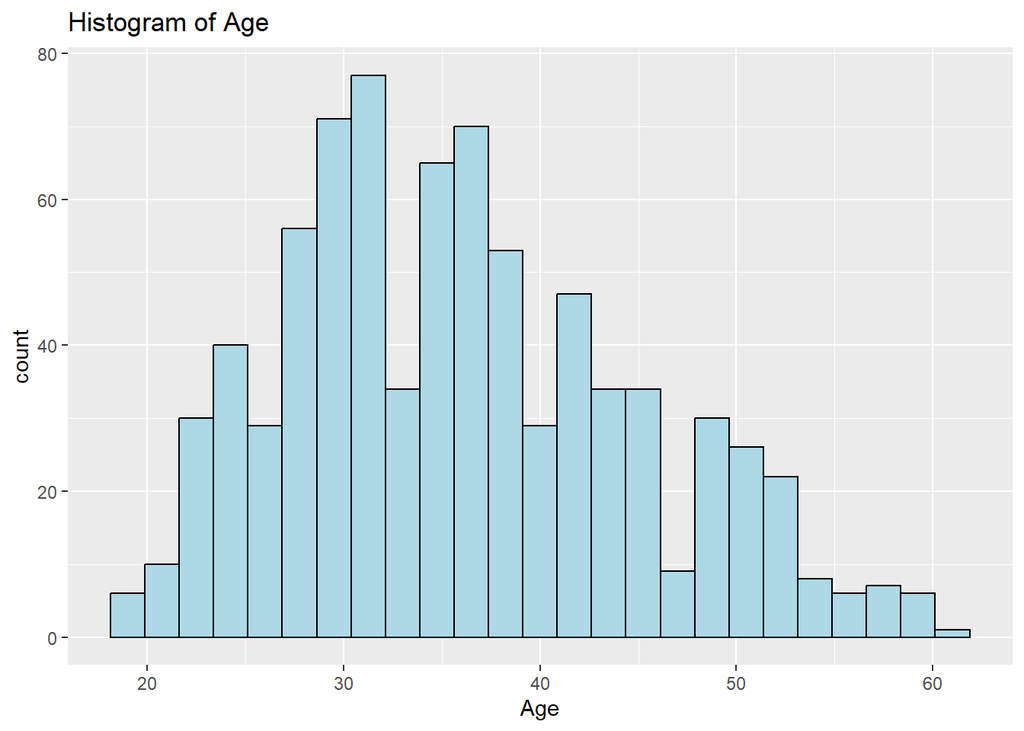

```r
ggplot(ad_train, aes(x = Age)) +
  geom_histogram(bins = 25, fill = "lightblue", color = "black") +
  labs(x = "Age", title = "Histogram of Age")
```

The distribution shows a main mode between 30 and 35 years, indicating that most users fall within this age range. Additionally, the data distribution has a slight positive skew, meaning that most of the data is concentrated around the mean, with a tail extending towards higher ages.

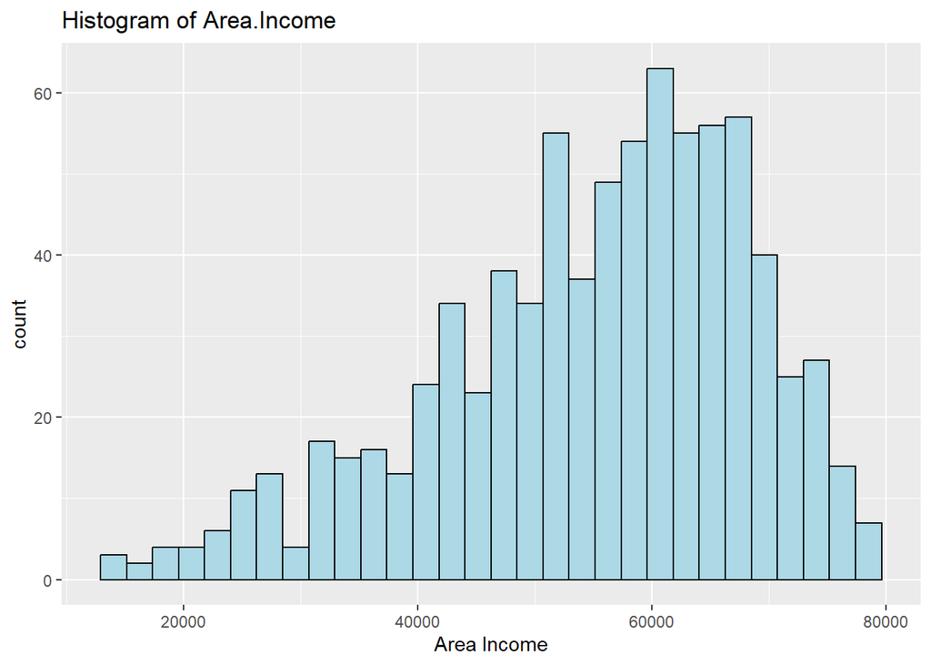

```r
ggplot(ad_train, aes(x = Area.Income)) +
  geom_histogram(bins = 30, fill = "lightblue", color = "black") +
  labs(x = "Area Income", title = "Histogram of Area.Income")
```

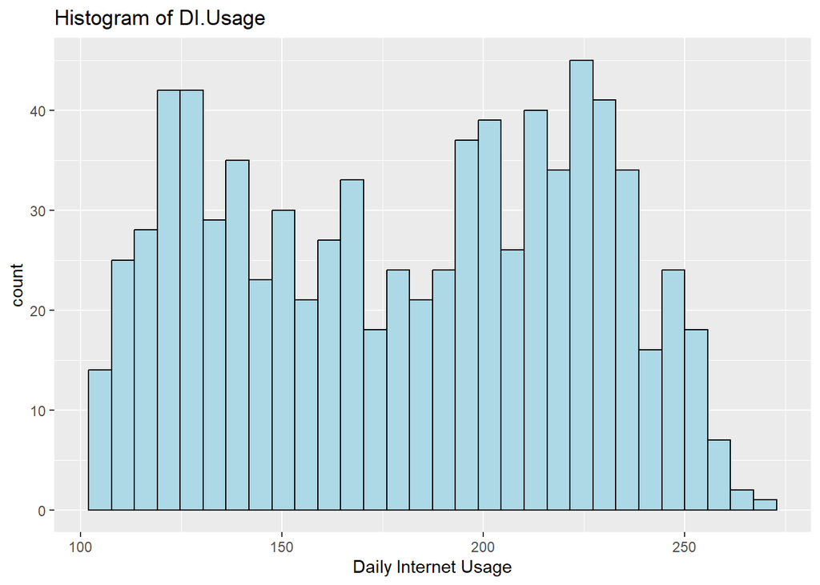

```r
ggplot(ad_train, aes(x = DI.Usage)) +
  geom_histogram(bins = 30, fill = "lightblue", color = "black") +
  labs(x = "Daily Internet Usage", title = "Histogram of DI.Usage")
```

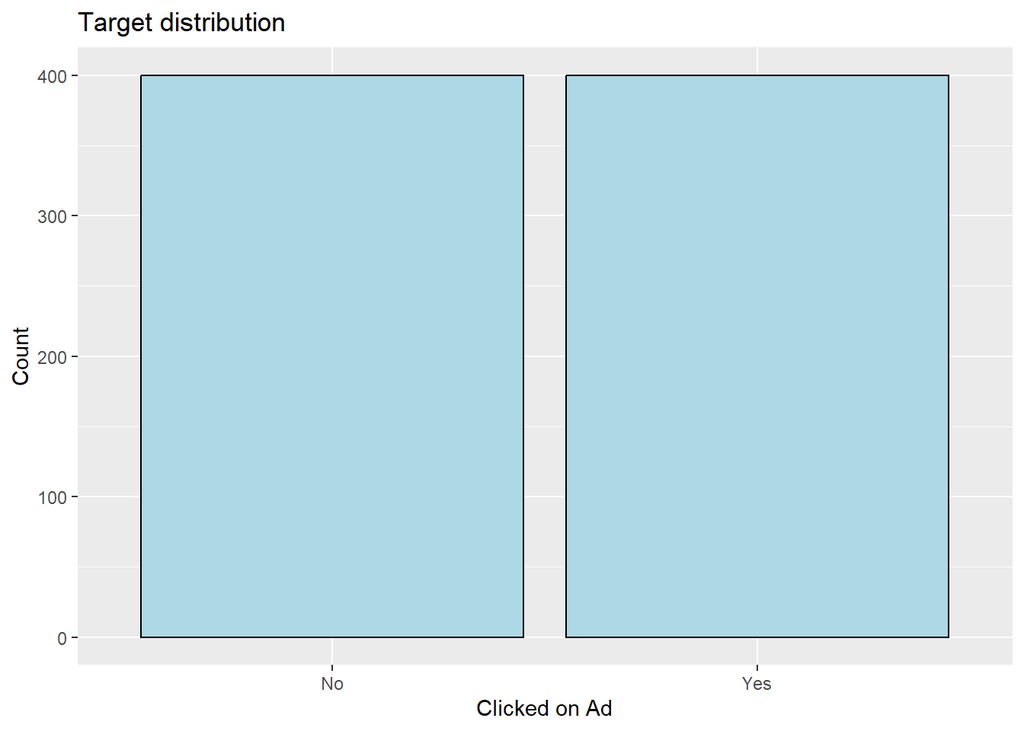

```r
ggplot(ad_train, aes(x = Clicked.on.Ad)) +
  geom_bar(fill = "lightblue", color = "black") +
  labs(x = "Clicked on Ad", y = "Count", title = "Target distribution")
```

The data distribution is uniform, meaning it is perfectly symmetrical.

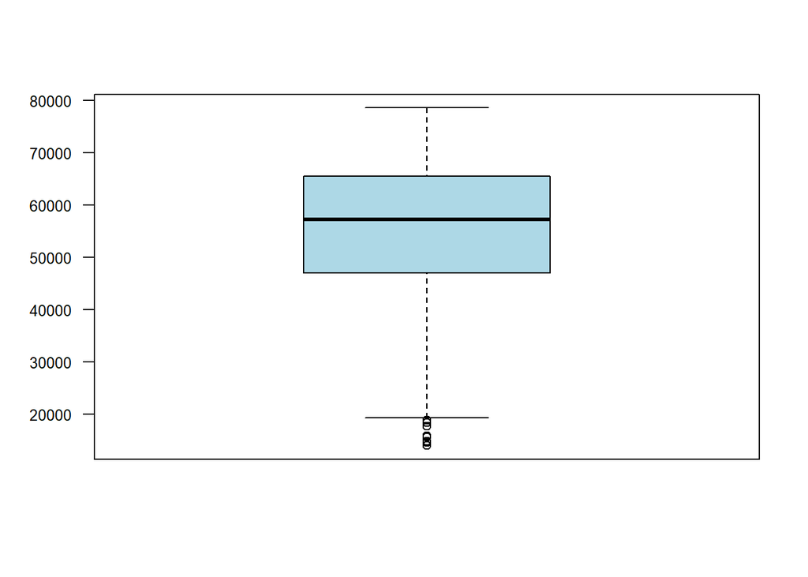

```r
boxplot(ad_train_num$Area.Income, col="lightblue", las=1, cex.axis=0.8)
```

The only boxplot that makes sense to display is *Area.Income*, as it is the only one with outliers. Additionally, a simultaneous representation of all numerical variables would lead to a distorted visualization because *Area.Income* has a larger order of magnitude compared to the other variables.

```r
boxplot.stats(ad_train_num$Area.Income)$out
```

```
## [1] 17709.98 18819.34 15879.10 14775.50 13996.50 18368.57 14548.06 15598.29
```

### Some cross-analyses

Now we analyze the dependency between pairs of variables using a matrix scatter plot, which allows us to simultaneously observe all relationships between the variables.

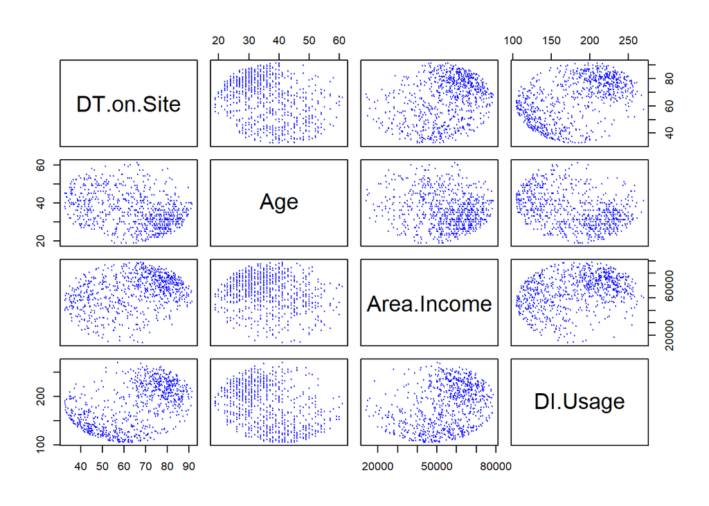

```r
# Scatterplot matrix only for continuous predictors
pairs(ad_train_cont, pch = 20, cex = 0.35, col = "blue")
```

The analysis of dependencies allows us to infer that there are no strong relationships between any particular pair of variables, as the distribution of points in all individual scatter plots appears rather scattered without a clear pattern.

However, we want to highlight two specific cases:  
1. The relationship between *Area.Income* and *DI.Usage*, which suggests that in areas with lower income, internet usage tends to be lower.

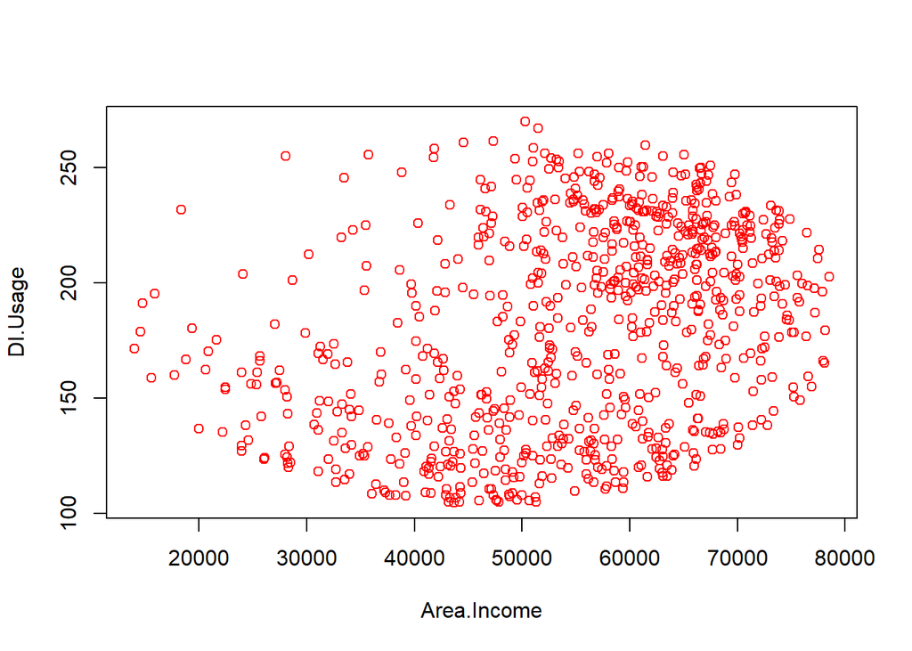

```r
plot(ad_train$Area.Income, ad_train$DI.Usage,
     col="red", xlab="Area.Income", ylab="DI.Usage")
```

2. The relationship between *Age* and *DI.Usage*, indicating that at an older age, daily internet usage is not high.

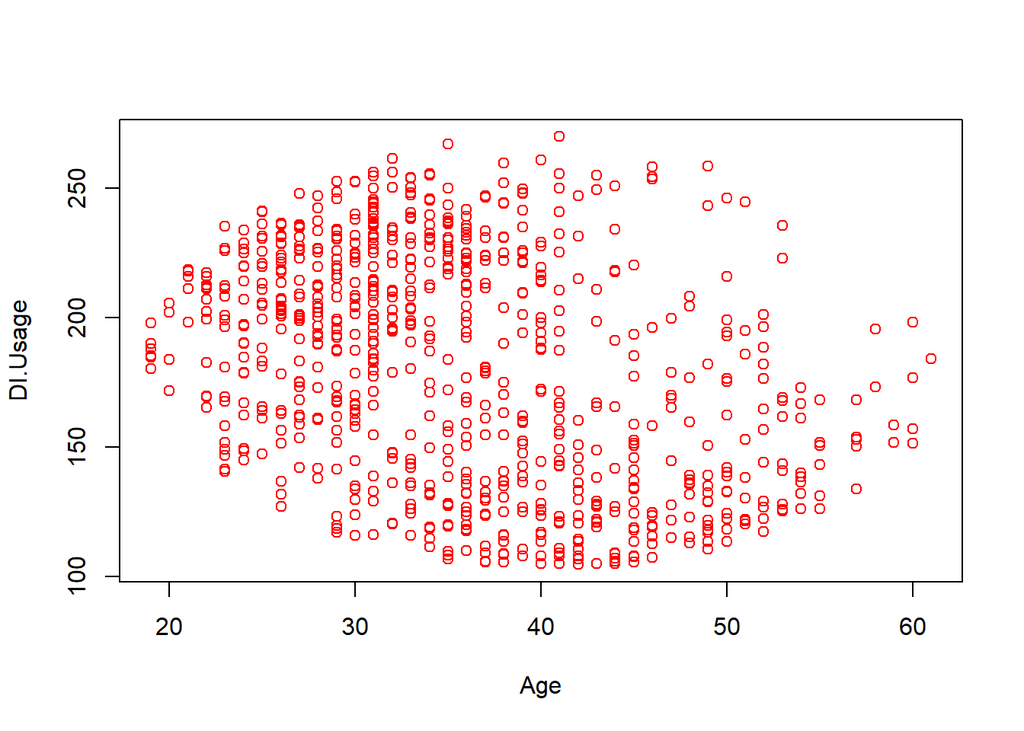

```r
plot(ad_train$Age, ad_train$DI.Usage,
     col="red", xlab="Age", ylab="DI.Usage")
```

## 1.4. Analysis of the dependency

Dependency analysis is a crucial step useful to comprehend relations between indipendent variables and dependent one (*Clicked.on.Ad*).

```r
N<-nrow(ad_train)
table(ad_train$Clicked.on.Ad)
```

```
##
##  No Yes
## 400 400
```

```r
round(table(ad_train$Clicked.on.Ad)/N*100,2)
```

```
##
##  No Yes
##  50  50
```

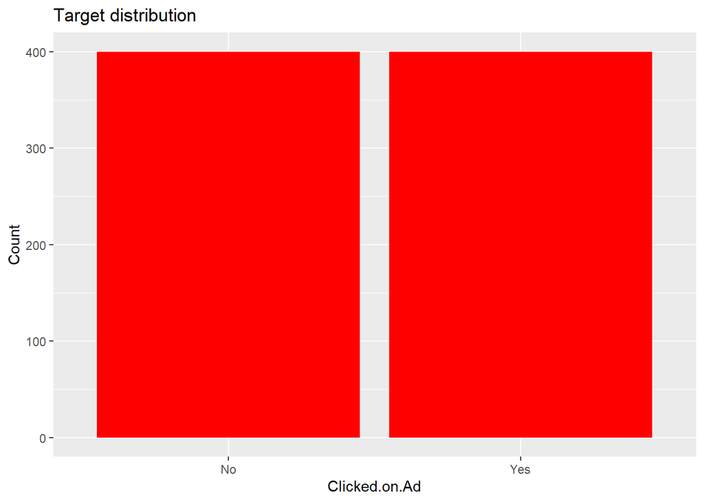

```r
ggplot(ad_train, aes(x = Clicked.on.Ad)) +
  geom_bar(fill = "red") +
  labs(title = "Target distribution", y = "Count")
```

Our target variable has a 50% probability, with an evenly distributed split between the two classes: 400 observations for class “1” and 400 observations for class “0”. The balanced distribution of the target variable prevents class imbalance issues. This ensures a less biased model and facilitates the identification of truly informative features.

### Analysis of the conditional distributions

The analysis of conditional distributions helps characterize the statistical profiles of the target classes, highlighting differences and patterns between “0” and “1” observations.

#### Distribution of *Age* and *Clicked.on.AD*

Consider the plot of the conditional distribution: *Age* conditioning on *Not Clicked=0* and *Clicked=1*.

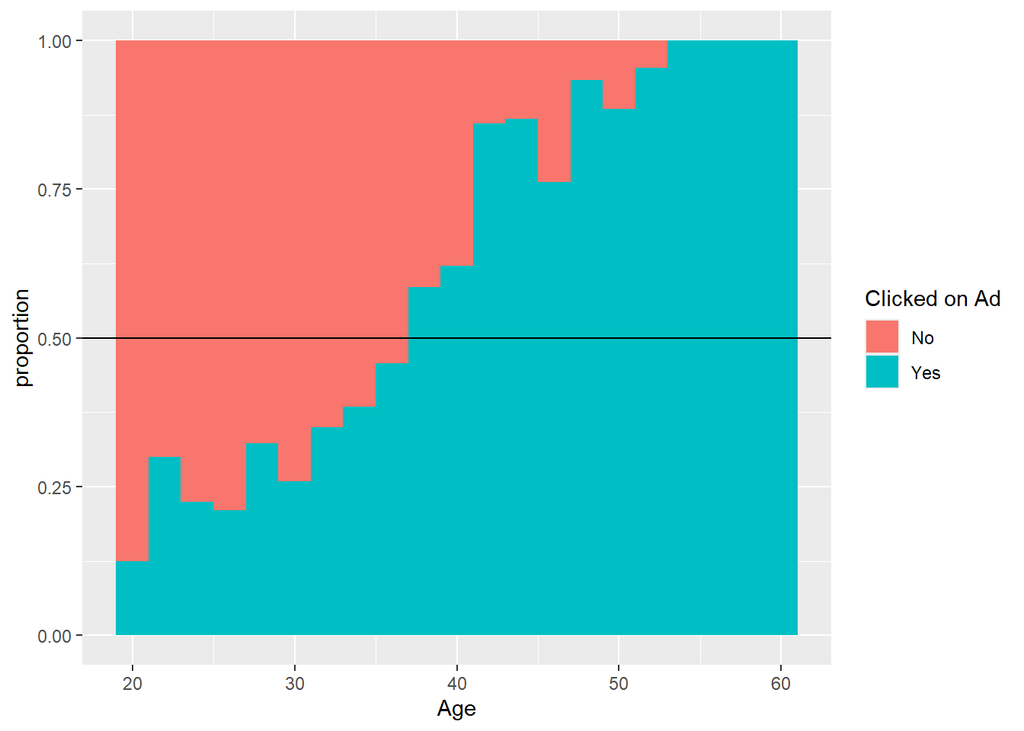

```r
ggplot(ad_train, aes(x = Age, fill = Clicked.on.Ad)) +
  geom_histogram(binwidth = 2, position = "fill") +
  geom_hline(yintercept = 0.5) +
  labs(y = "proportion", fill = "Clicked on Ad")
```

The horizontal line in the graph, which refers to the 0.50 value on the Y-axis, indicates the exact point where the proportion of those who clicked and those who did not click is 50%.

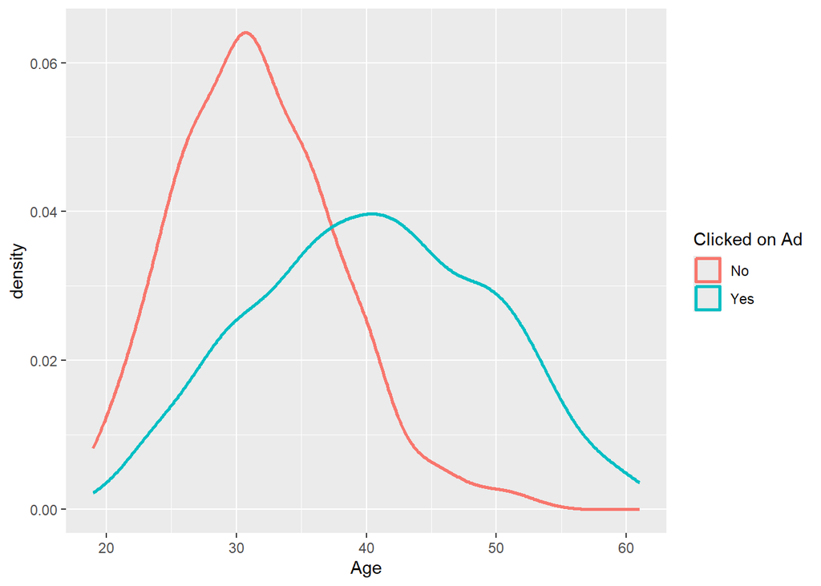

```r
ggplot(ad_train, aes(x = Age, color = Clicked.on.Ad)) +
  geom_density(linewidth = 1) +
  labs(color = "Clicked on Ad")
```

The curves exhibit different shapes and symmetries, with the orange curve (representing non-clicks) having a long right tail. This suggests that after the age of 40, users are significantly more likely to click on ads. The partial but not complete overlap of the curves indicates that age has a notable influence on clicking behavior, though it is not the sole determining factor.

#### Distribution of *DT.on.Site* and *Clicked.on.Ad*

We can Analyze the conditional distribution of *Clicked.on.Ad* conditioning on *DT.on.Site* using the stacked barplot:

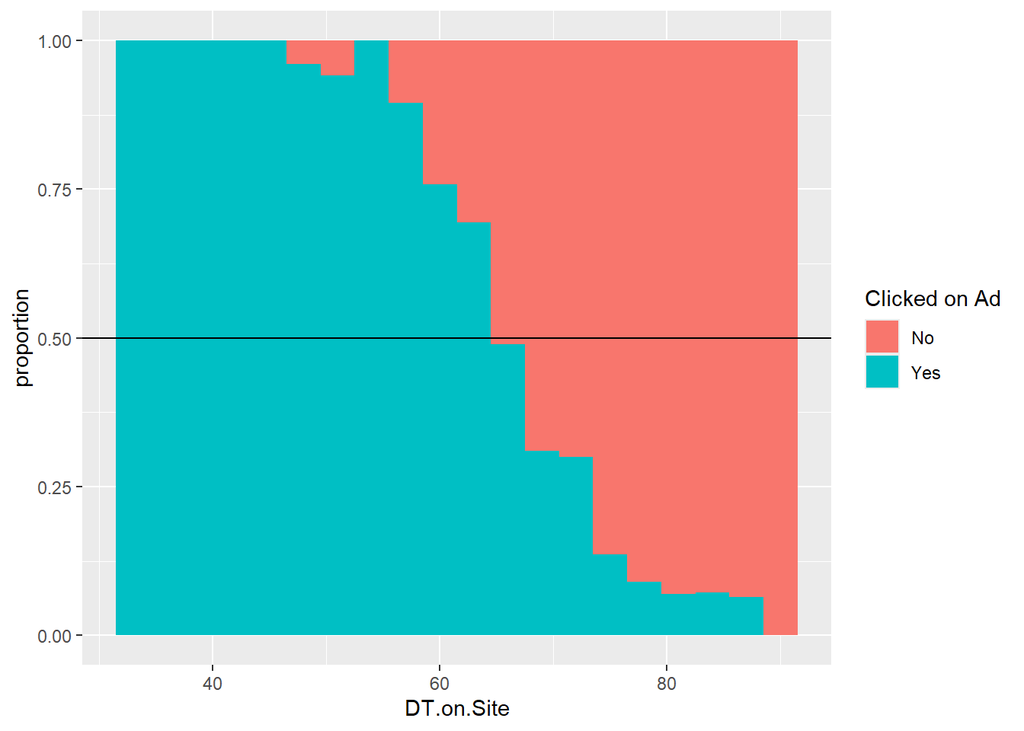

```r
ggplot(ad_train, aes(x = DT.on.Site, fill = Clicked.on.Ad)) +
  geom_histogram(binwidth = 3, position = "fill") +
  geom_hline(yintercept = 0.5) +
  labs(y = "proportion", fill = "Clicked on Ad")
```

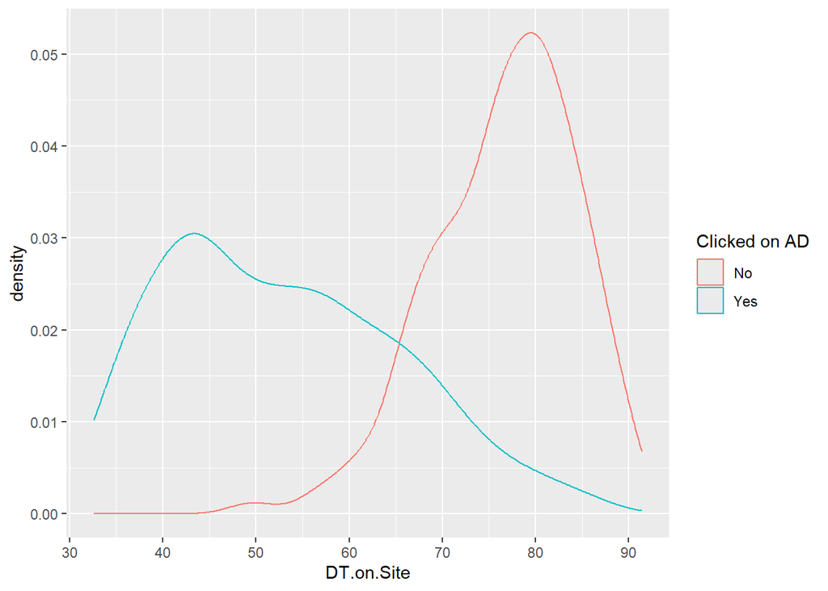

```r
 ggplot(ad_train_num, aes(DT.on.Site)) +
  geom_density(aes(color = factor(Clicked.on.Ad)))+
  scale_color_discrete(name="Clicked on AD")
```

Both density curves exhibit tails, although the one associated with non-clicks has a longer left tail compared to the curve for clicks. The limited overlap between the two curves suggests that the variable DT has a strong influence on *Clicked.on.Ad*

```r
t.test(DT.on.Site ~ Clicked.on.Ad, data = ad_train)
```

```
##
##  Welch Two Sample t-test
##
## data:  DT.on.Site by Clicked.on.Ad
## t = 32.268, df = 663.66, p-value < 2.2e-16
## alternative hypothesis: true difference in means between group No and group Yes is not equal to 0
## 95 percent confidence interval:
##  22.25218 25.13577
## sample estimates:
##  mean in group No mean in group Yes
##          76.64885          52.95488
```

#### Distribution of *DI.Usage* and *Clicked.on.Ad*

Consider the cross-analysis between the variables *DI.Usage* and *Clicked.on.Ad.* *DI.Usage* is a numerical and continuous variable.

Analyze the conditional distribution of *Clicked.on.Ad* conditioning on *DI.Usage* using the stacked barplot.

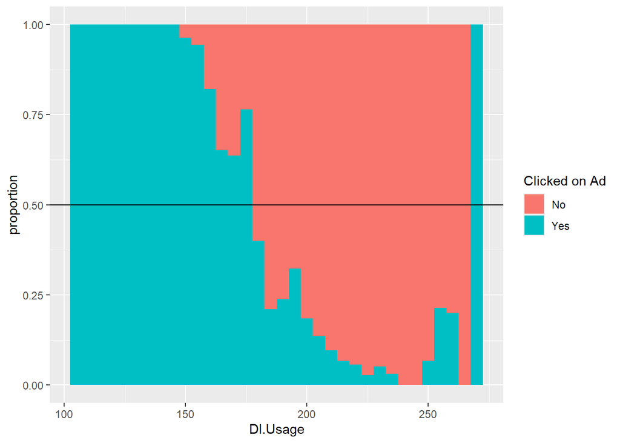

```r
ggplot(ad_train, aes(x = DI.Usage, fill = Clicked.on.Ad)) +
  geom_histogram(binwidth = 5, position = "fill") +
  geom_hline(yintercept = 0.5) +
  labs(y = "proportion", fill = "Clicked on Ad")
```

From the graph we can say that there is an inverse relationship between *DI.Usage* and the probability of a user clicking on an ad. We can deduce that users who spend less time on the internet tend to click on ads more, while those who use it more tend to click less. The variable *DI.Usage* appears to be an important predictive factor for *Click.on.Ad*.

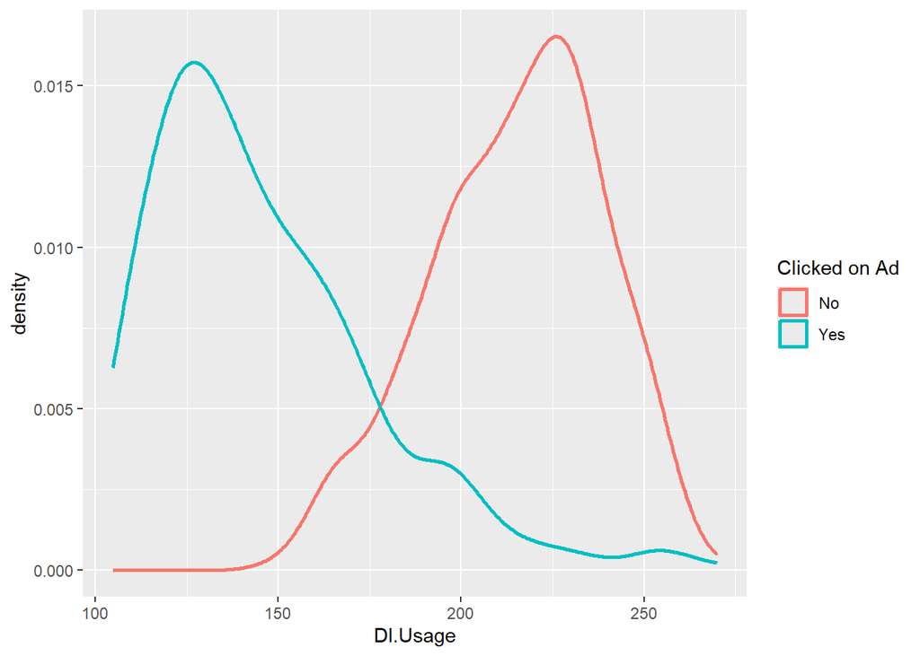

```r
ggplot(ad_train, aes(x = DI.Usage, color = Clicked.on.Ad)) +
  geom_density(linewidth = 1) +
  labs(color = "Clicked on Ad")
```

These graphs show the distribution of DI.Usage for each group (click and non-click), highlighting the differences in their distributions.For users who did not click, the distribution exhibits a slight left skew, with a higher concentration around 210-230. For users who clicked, the distribution is concentrated around 120-140 and is right-skewed, with a long tail extending towards higher values.The two graphs complement each other, providing a deeper understanding of the relationship between the two variables.

#### Distribution of *Area.Income* and *Clicked.on.Ad*

Consider the cross-analysis between the variables *Area.Income* and *Clicked.on.Ad*. Area.Income is a numerical and continuous variable.

Analyze the conditional distribution of *Clicked.on.Ad* conditioning on *Area.Income* using the stacked barplot.

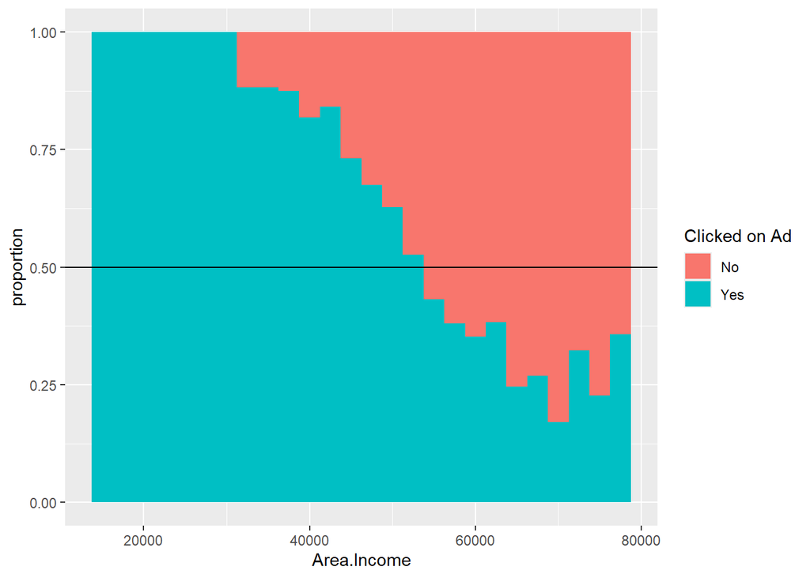

```r
ggplot(ad_train, aes(x = Area.Income, fill = Clicked.on.Ad)) +
  geom_histogram(binwidth = 2500, position = "fill") +
  geom_hline(yintercept = 0.5) +
  labs(y = "proportion", fill = "Clicked on Ad")
```

From the graph, we can infer that the higher the income of the area, the lower the likelihood that the user will click on the ad, although the percentage of users who do not click on the ad is never 100%. Therefore, we can state that there is a negative correlation between the two variables.

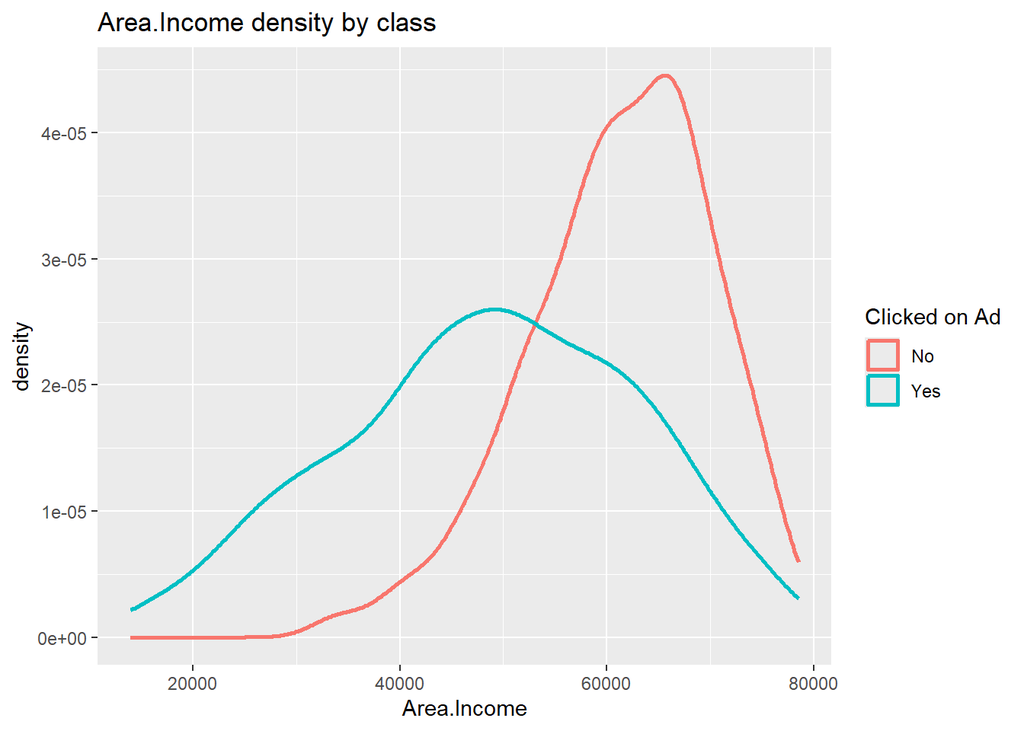

```r
ggplot(ad_train, aes(x = Area.Income, color = Clicked.on.Ad)) +
  geom_density(linewidth = 1) +
  labs(color = "Clicked on Ad", title = "Area.Income density by class")
```

#### Distribution of *Country* and *Clicked.on.Ad*

Consider the cross-analysis between the variables *Country* and *Clicked.on.Ad*.

```r
top_20_values <- ad_train %>%
  count(Country, sort = TRUE) %>%
  slice_max(order_by = n, n = 20)

ad_train_subset <- ad_train %>%
  filter(Country %in% top_20_values$Country)
```

```r
prop.table(table(ad_train_subset$Clicked.on.Ad, ad_train_subset$Country), 2) * 100
```

```
##
##         Belarus   Bolivia Bosnia and Herzegovina  Bulgaria   Burundi  Cambodia
##   No   50.00000 100.00000               57.14286  33.33333  66.66667  71.42857
##   Yes  50.00000   0.00000               42.85714  66.66667  33.33333  28.57143
##
##       Christmas Island Costa Rica    Cyprus Czech Republic    France    Greece
##   No          33.33333   66.66667  33.33333       42.85714  44.44444  57.14286
##   Yes         66.66667   33.33333  66.66667       57.14286  55.55556  42.85714
##
##       Hong Kong    Jersey   Liberia Liechtenstein Luxembourg    Mexico
##   No   33.33333  33.33333  25.00000       0.00000   50.00000  33.33333
##   Yes  66.66667  66.66667  75.00000     100.00000   50.00000  66.66667
##
##       Micronesia Netherlands Antilles      Peru     Qatar Singapore    Turkey
##   No    50.00000             66.66667  33.33333  66.66667  83.33333  16.66667
##   Yes   50.00000             33.33333  66.66667  33.33333  16.66667  83.33333
##
##       Venezuela Western Sahara
##   No   50.00000       33.33333
##   Yes  50.00000       66.66667
```

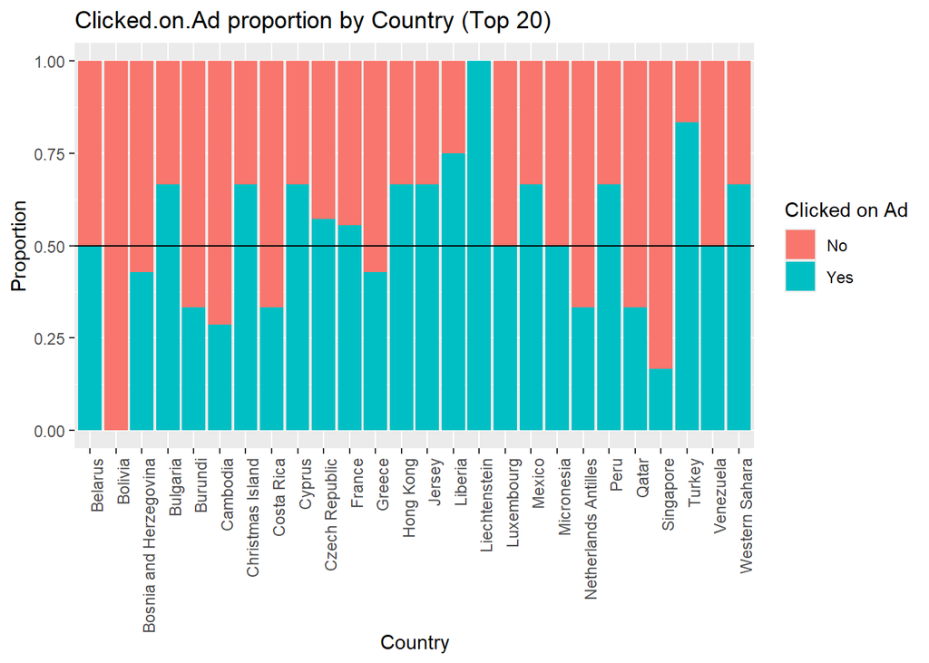

```r
ggplot(ad_train_subset, aes(x = Country, fill = Clicked.on.Ad)) +
  geom_bar(position = "fill") +
  geom_hline(yintercept = 0.5) +
  labs(y = "Proportion", fill = "Clicked on Ad",
       title = "Clicked.on.Ad proportion by Country (Top 20)") +
  theme(axis.text.x = element_text(angle = 90, hjust = 1))
```

## 2. Model Selection

### 2.1. Feature Selection and Resampling Strategy

Based on the Exploratory Data Analysis (EDA) conducted in the previous section, we identified that continuous variables such as `DT.on.Site`, `DI.Usage`, `Age`, and `Area.Income` exhibit strong relationships with the target variable `Clicked.on.Ad`. We will use these variables as our primary predictors. We will also include `Male` to evaluate if gender provides any marginal predictive power when combined with the other features. Variables with high cardinality or complex structures like `City`, `Country`, and `Timestamp` are excluded from these baseline models to maintain interpretability and prevent overfitting.

To rigorously evaluate our models and estimate their performance on unseen data, we apply a **10-Fold Cross-Validation** strategy. This technique splits the training data into 10 equal parts, training the model on 9 parts and validating it on the remaining 1, repeating this process 10 times to compute an average robust metric.

```r
# Load necessary libraries for modeling
library(caret)
library(MASS)
library(rpart)
library(rpart.plot)

# Set seed for reproducibility
set.seed(123)

# Define the training control (10-fold Cross-Validation)
train_control <- trainControl(method = "cv", number = 10)

# Define the formula to be used across all models
model_formula <- Clicked.on.Ad ~ DT.on.Site + Age + Area.Income + DI.Usage + Male
```